# Personality Analyses Final

# PCA (Varimax rotation)

## Preparing for PCA

Here we carry out the Bartlett’s test (for correlation) and the KMO. Bartlett’s test df = 630, p-value < 0.001, good! KMO is extremely poor at 0.22. These are sensitivity analyses. Note a KMO test is not needed for PCA and is usually used for factor analysis

```r
library(psych)
library(tibble)

behaviour_data <- personality_matrix %>%
  column_to_rownames("Animal_ID")

behaviour_z <- scale(behaviour_data)

cor_matrix <- cor(behaviour_z)
cortest.bartlett(cor_matrix,
                 n = nrow(behaviour_z))
```

```
$chisq
[1] 1004.204

$p.value
[1] 1.247719e-19

$df
[1] 630
```

```r
KMO(cor_matrix)
```

```
Kaiser-Meyer-Olkin factor adequacy
Call: KMO(r = cor_matrix)
Overall MSA =  0.22
MSA for each item =
        (give) Aggression      (receive) Aggression           (receive) Groom
                     0.36                      0.36                      0.10
          (receive) Mount                  Approach                     Avoid
                     0.40                      0.62                      0.31
               Brow flash                      Feed                    Forage
                     0.60                      0.09                      0.08
               Locomotion                 Make room        Object interaction
                     0.20                      0.63                      0.03
        Open-mouth threat      Passive body contact                      Rest
                     0.53                      0.37                      0.09
               Self-groom   Silent bared-teeth face                     Stare
                     0.06                      0.47                      0.19
         Stationary alone   Stationary in proximity             Vigilant scan
                     0.13                      0.13                      0.17
             Vocalisation         (give) Food share                   Display
                     0.25                      0.57                      0.51
                     Play                    Reject                  Supplant
                     0.68                      0.37                      0.41
             (give) Mount              (give) Groom                     Cower
                     0.61                      0.07                      0.51
                Lip smack Other species interaction          Initiate contact
                     0.62                      0.47                      0.36
               Masturbate            Muzzle contact               Hold others
                     0.56                      0.51                      0.03
```

## Running parallel analysis

This determines how many components are relevant for analysis. 3 components suggested here.

```
Parallel analysis suggests that the number of factors =  NA  and the number of components =  3
```

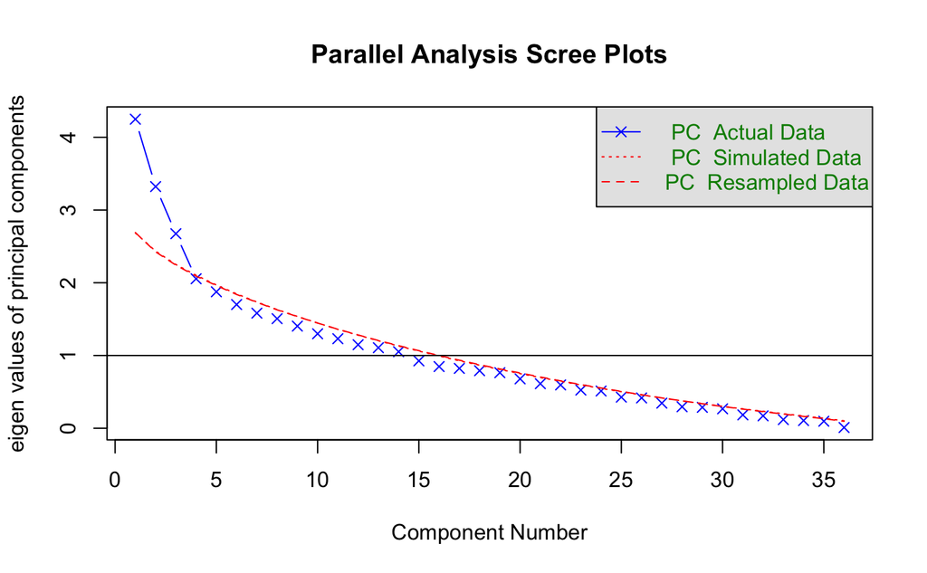

```r
parallel <- fa.parallel(
  behaviour_z,
  fa = "pc",
  n.iter = 1000
)
```

## Kaiser correction

This also examines how many components to analyse. 14 components suggested here

```r
eigenvalues <- eigen(cor_matrix)$values
eigenvalues
```

```
 [1] 4.248705595 3.322085729 2.674403918 2.054887239 1.875735621 1.700682325 1.581901781 1.506300974 1.404171171
[10] 1.298663708 1.230706174 1.148130597 1.107076324 1.052116927 0.925912368 0.847931717 0.822485452 0.790842510
[19] 0.763661709 0.678853094 0.612264364 0.595427867 0.524568378 0.511676578 0.426961459 0.416412093 0.344835775
[28] 0.295282216 0.286983056 0.266803617 0.183584234 0.170272158 0.118550469 0.105217005 0.096028606 0.009877193
```

```r
sum(eigenvalues > 1)
```

```
[1] 14
```

## Carrying out PCA

Loading of 0.30 for full loading

```r
pca <- principal(
  behaviour_z,
  nfactors = 3,
  rotate = "varimax",
  scores = TRUE
)

print(
  pca,
  cutoff = 0.30,
  sort = TRUE
)
```

```
Principal Components Analysis
Call: principal(r = behaviour_z, nfactors = 3, rotate = "varimax",
    scores = TRUE)
Standardized loadings (pattern matrix) based upon correlation matrix
                          item   RC1   RC2   RC3     h2   u2 com
Approach                     5  0.77  0.10  0.03 0.6098 0.39 1.0
Other species interaction   32  0.67  0.16  0.02 0.4805 0.52 1.1
Reject                      26  0.62 -0.01  0.10 0.3985 0.60 1.0
Stationary in proximity     20  0.58 -0.14 -0.22 0.4022 0.60 1.4
(give) Food share           23  0.57 -0.02  0.08 0.3318 0.67 1.0
Make room                   11 -0.53 -0.09  0.01 0.2899 0.71 1.1
Lip smack                   31  0.51  0.25  0.07 0.3306 0.67 1.5
Brow flash                   7 -0.48  0.21 -0.16 0.3024 0.70 1.6
Stationary alone            19 -0.45 -0.39  0.02 0.3517 0.65 2.0
Initiate contact            33 -0.25  0.10  0.06 0.0752 0.92 1.4
Stare                       18 -0.24 -0.14  0.00 0.0754 0.92 1.6
Object interaction          12 -0.15  0.08 -0.14 0.0499 0.95 2.5
Display                     24 -0.16  0.65  0.05 0.4511 0.55 1.1
(give) Mount                28 -0.11  0.64 -0.15 0.4391 0.56 1.2
Open-mouth threat           13  0.28  0.61 -0.01 0.4489 0.55 1.4
Muzzle contact              35  0.15  0.59  0.04 0.3698 0.63 1.1
(receive) Aggression         2 -0.32  0.53  0.09 0.3898 0.61 1.7
(give) Aggression            1 -0.24  0.49  0.11 0.3097 0.69 1.6
Play                        25  0.13  0.47  0.15 0.2552 0.74 1.4
Forage                       9 -0.18 -0.37  0.00 0.1677 0.83 1.5
Vocalisation                22 -0.04  0.33  0.00 0.1129 0.89 1.0
Self-groom                  16 -0.06  0.33 -0.28 0.1933 0.81 2.0
Rest                        15 -0.15 -0.32 -0.25 0.1874 0.81 2.4
Passive body contact        14  0.24  0.31 -0.24 0.2064 0.79 2.8
Feed                         8  0.15  0.30  0.23 0.1664 0.83 2.4
Locomotion                  10 -0.16  0.12  0.78 0.6482 0.35 1.1
Vigilant scan               21  0.17  0.30  0.70 0.6117 0.39 1.5
(receive) Groom              3 -0.05  0.09 -0.62 0.3900 0.61 1.1
(give) Groom                29  0.06  0.00 -0.48 0.2351 0.76 1.0
Avoid                        6 -0.21 -0.20  0.46 0.2966 0.70 1.8
Cower                       30  0.17  0.16  0.44 0.2454 0.75 1.6
(receive) Mount              4 -0.14 -0.05  0.38 0.1680 0.83 1.3
Supplant                    27  0.13  0.04  0.25 0.0838 0.92 1.6
Silent bared-teeth face     17 -0.20  0.15  0.25 0.1278 0.87 2.6
Masturbate                  34 -0.02  0.03 -0.19 0.0360 0.96 1.1
Hold others                 36 -0.01 -0.04 -0.08 0.0073 0.99 1.5

                       RC1  RC2  RC3
SS loadings           3.89 3.48 2.87
Proportion Var        0.11 0.10 0.08
Cumulative Var        0.11 0.20 0.28
Proportion Explained  0.38 0.34 0.28
Cumulative Proportion 0.38 0.72 1.00

Mean item complexity =  1.5
Test of the hypothesis that 3 components are sufficient.

The root mean square of the residuals (RMSR) is  0.07
 with the empirical chi square  384.48  with prob <  1
 0.3
Fit based upon off diagonal values = 0.82
```

```r
# Variance explained per axis
variance_explained <- pca$Vaccounted
variance_explained
```

```
                            RC1        RC2        RC3
SS loadings           3.8922934 3.48035104 2.87255082
Proportion Var        0.1081193 0.09667642 0.07979308
Cumulative Var        0.1081193 0.20479568 0.28458876
Proportion Explained  0.3799140 0.33970568 0.28038029
Cumulative Proportion 0.3799140 0.71961971 1.00000000
```

```r
# extracting pca scores
pca_scores <- as.data.frame(pca$scores) %>%
  rownames_to_column("Animal_ID")

# combining pcoa_scores with rank and rates
pca_scores_rankrate <- left_join(pca_scores, rank_rate, by = "Animal_ID")

write.csv(pca_scores_rankrate, "~/Savolainen Lab/SSB/Data/Personality/pca_scores_rankrate.csv")
```

### PCA (cut-off = 0.40)

```r
pca <- principal(
  behaviour_z,
  nfactors = 3,
  rotate = "varimax",
  scores = TRUE
)

print(
  pca,
  cutoff = 0.40,
  sort = TRUE
)
```

```
Principal Components Analysis
Call: principal(r = behaviour_z, nfactors = 3, rotate = "varimax",
    scores = TRUE)
Standardized loadings (pattern matrix) based upon correlation matrix
                          item   RC1   RC2   RC3     h2   u2 com
Approach                     5  0.77  0.10  0.03 0.6098 0.39 1.0
Other species interaction   32  0.67  0.16  0.02 0.4805 0.52 1.1
Reject                      26  0.62 -0.01  0.10 0.3985 0.60 1.0
Stationary in proximity     20  0.58 -0.14 -0.22 0.4022 0.60 1.4
(give) Food share           23  0.57 -0.02  0.08 0.3318 0.67 1.0
Make room                   11 -0.53 -0.09  0.01 0.2899 0.71 1.1
Lip smack                   31  0.51  0.25  0.07 0.3306 0.67 1.5
Brow flash                   7 -0.48  0.21 -0.16 0.3024 0.70 1.6
Stationary alone            19 -0.45 -0.39  0.02 0.3517 0.65 2.0
Initiate contact            33 -0.25  0.10  0.06 0.0752 0.92 1.4
Stare                       18 -0.24 -0.14  0.00 0.0754 0.92 1.6
Object interaction          12 -0.15  0.08 -0.14 0.0499 0.95 2.5
Display                     24 -0.16  0.65  0.05 0.4511 0.55 1.1
(give) Mount                28 -0.11  0.64 -0.15 0.4391 0.56 1.2
Open-mouth threat           13  0.28  0.61 -0.01 0.4489 0.55 1.4
Muzzle contact              35  0.15  0.59  0.04 0.3698 0.63 1.1
(receive) Aggression         2 -0.32  0.53  0.09 0.3898 0.61 1.7
(give) Aggression            1 -0.24  0.49  0.11 0.3097 0.69 1.6
Play                        25  0.13  0.47  0.15 0.2552 0.74 1.4
Forage                       9 -0.18 -0.37  0.00 0.1677 0.83 1.5
Vocalisation                22 -0.04  0.33  0.00 0.1129 0.89 1.0
Self-groom                  16 -0.06  0.33 -0.28 0.1933 0.81 2.0
Rest                        15 -0.15 -0.32 -0.25 0.1874 0.81 2.4
Passive body contact        14  0.24  0.31 -0.24 0.2064 0.79 2.8
Feed                         8  0.15  0.30  0.23 0.1664 0.83 2.4
Locomotion                  10 -0.16  0.12  0.78 0.6482 0.35 1.1
Vigilant scan               21  0.17  0.30  0.70 0.6117 0.39 1.5
(receive) Groom              3 -0.05  0.09 -0.62 0.3900 0.61 1.1
(give) Groom                29  0.06  0.00 -0.48 0.2351 0.76 1.0
Avoid                        6 -0.21 -0.20  0.46 0.2966 0.70 1.8
Cower                       30  0.17  0.16  0.44 0.2454 0.75 1.6
(receive) Mount              4 -0.14 -0.05  0.38 0.1680 0.83 1.3
Supplant                    27  0.13  0.04  0.25 0.0838 0.92 1.6
Silent bared-teeth face     17 -0.20  0.15  0.25 0.1278 0.87 2.6
Masturbate                  34 -0.02  0.03 -0.19 0.0360 0.96 1.1
Hold others                 36 -0.01 -0.04 -0.08 0.0073 0.99 1.5

                       RC1  RC2  RC3
SS loadings           3.89 3.48 2.87
Proportion Var        0.11 0.10 0.08
Cumulative Var        0.11 0.20 0.28
Proportion Explained  0.38 0.34 0.28
Cumulative Proportion 0.38 0.72 1.00

Mean item complexity =  1.5
Test of the hypothesis that 3 components are sufficient.

The root mean square of the residuals (RMSR) is  0.07
 with the empirical chi square  384.48  with prob <  1
 0.4
Fit based upon off diagonal values = 0.82
```

## Extracting loadings for each RC

```r
loadings_df <- as.data.frame(unclass(pca$loadings)) %>%
  rownames_to_column("Behaviour")
loadings_df
```

| Behaviour | RC1 | RC2 | RC3 |
| --- | --- | --- | --- |
| (give) Aggression | -0.24367282 | 0.487814025 | 0.111074821 |
| (receive) Aggression | -0.31964073 | 0.528822764 | 0.089065840 |
| (receive) Groom | -0.05314608 | 0.087416303 | -0.616034055 |
| (receive) Mount | -0.14495135 | -0.051740273 | 0.379852887 |
| Approach | 0.77341720 | 0.103885088 | 0.028691371 |
| Avoid | -0.20506401 | -0.199164245 | 0.463525172 |
| Brow flash | -0.48464215 | 0.207084989 | -0.157053933 |
| Feed | 0.14915059 | 0.304251033 | 0.227232754 |
| Forage | -0.18475282 | -0.365402991 | -0.004038039 |
| Locomotion | -0.15925700 | 0.119816232 | 0.780025407 |

[output cut: 26 more lines]

```r
write.csv(loadings_df, "~/Savolainen Lab/SSB/Data/Personality/pca_loadings_all.csv")

# RC1
RC1_loadings <- loadings_df %>%
  filter(abs(RC1) >= 0.40) %>%
  arrange(desc(abs(RC1))) %>%
  select(c("Behaviour", "RC1"))

# RC2
RC2_loadings <- loadings_df %>%
  filter(abs(RC2) >= 0.40) %>%
  arrange(desc(abs(RC2))) %>%
  select(c("Behaviour", "RC2"))

# RC3
RC3_loadings <- loadings_df %>%
  filter(abs(RC3) >= 0.40) %>%
  arrange(desc(abs(RC3))) %>%
  select(c("Behaviour", "RC3"))

RC1_loadings
```

| Behaviour | RC1 |
| --- | --- |
| Approach | 0.7734172 |
| Other species interaction | 0.6749548 |
| Reject | 0.6239493 |
| Stationary in proximity | 0.5761527 |
| (give) Food share | 0.5698541 |
| Make room | -0.5299552 |
| Lip smack | 0.5107622 |
| Brow flash | -0.4846421 |
| Stationary alone | -0.4485533 |

```r
RC2_loadings
```

| Behaviour | RC2 |
| --- | --- |
| Display | 0.6493369 |
| (give) Mount | 0.6368083 |
| Open-mouth threat | 0.6095999 |
| Muzzle contact | 0.5881294 |
| (receive) Aggression | 0.5288228 |
| (give) Aggression | 0.4878140 |
| Play | 0.4654081 |

```r
RC3_loadings
```

| Behaviour | RC3 |
| --- | --- |
| Locomotion | 0.7800254 |
| Vigilant scan | 0.7021666 |
| (receive) Groom | -0.6160341 |
| (give) Groom | -0.4812570 |
| Avoid | 0.4635252 |
| Cower | 0.4367787 |

```r
write.csv(RC1_loadings, "~/Savolainen Lab/SSB/Data/Personality/rc1_loading.csv")
write.csv(RC2_loadings, "~/Savolainen Lab/SSB/Data/Personality/rc2_loading.csv")
write.csv(RC3_loadings, "~/Savolainen Lab/SSB/Data/Personality/rc3_loading.csv")
```